# Stuart Foundation - Data Analysis

## Deliverable 1 - Linked learning outcomes:

1. Health Professions High School student outcomes vs. SCUSD district overall
2. School of Science & Engineering High School student outcomes vs. SCUSD district overall
3. Average HPHS/SES (linked learning schools) student outcomes vs. SCUSD district overall

```python
import xlrd
import pprint
import unicodecsv
import matplotlib.pyplot as plt
import numpy as np
import pandas as pd
import seaborn as sns
import csv as csv
from IPython.display import display, HTML
import IPython.core.display as di
%matplotlib inline

di.display_html('''<button onclick="jQuery('.input_area').toggle(); jQuery('.prompt').toggle();">Toggle code</button>''', raw=True)
```

```python
#Transform excel file into pandas dataframe. Ensure first sheet in excel file has data, first row contains column headings
def excel_to_dataframe(datafile):
    workbook = xlrd.open_workbook(datafile)
    sheet = workbook.sheet_by_index(0)
    #Ensure first sheet has the data
    data = [[sheet.cell_value(r, col)
                for col in range(sheet.ncols)]
                    for r in range(sheet.nrows)]
    headers = data.pop(0)
    df = pd.DataFrame(data, columns = headers)
    return df
```

```python
def fancydisplay(df):
    display(HTML(df.to_html(index=False)))
    return
```

### California Datasets

Public Schools: contains all public schools, CDS code, grades served. Year: 2016, updated daily. Source: http://www.cde.ca.gov/ds/si/ds/pubschls.asp

Enrollment: enrollment by grade, disaggregated by ehtnicity and gender. Years: 11/12, 12/13, 13/14, 14/15, 15/16. Source: http://www.cde.ca.gov/ds/sd/sd/filesenr.asp

API: School results on API (more details below table), test discontinued after 2014. Years: 3yr weighted average 11-14; 13 [Not including more years because it's old]. Source: http://www.cde.ca.gov/ta/ac/ap/apidatafiles.asp#updates

AYP: School results on AYP - % ELA and Math proficient, graduation rates, reporting discontinued after 2015. Years: 2013, 2014, 2015. Source: http://www.cde.ca.gov/ta/ac/ay/aypdatafiles.asp [Note: attendance rate is reported under AYP but only for K-8 grades; can be used to compare middle school performance.]

Graduates: Number of graduates from 12th grade, number of graduates meeting UC/CSU standards. Use for graduation rates when comparing enrollment for same year. Years: 10/11, 11/12, 12/13, 13/14, 14/15. Source: http://www.cde.ca.gov/ds/sd/sd/filesgrads.asp

Truancy: Number of truants per school & rates of truancy, not separated by grade. Years: 12/13, 13/14, 14/15. Source: http://www.cde.ca.gov/ds/sd/sd/filestd.asp Note: Census Enrollment: The total unique or unduplicated number of primary enrollments on the CALPADS Fall 1 Census Day, which is the first Wednesday in October of the associated academic year. Cumulative Enrollment: The total number of unique or unduplicated primary, secondary, and short-term enrollments within the academic year (July 1 to June 30), regardless of whether the student is enrolled multiple times within a school or district.

Suspension/Expulsion: Reported cases of suspensions and expulsions, separate row for each instance. Years: 11/12, 12/13, 13/14, 14/15. Source: http://www.cde.ca.gov/ds/sd/sd/filesesd.asp

```python
#Import California datasets
pubschls = excel_to_dataframe("pubschls.xls")

    # Testing including them only by txt file. could that work?
    # Issue: when viewing in excel,
enrl1516 = pd.read_table("filesenr1516.asp.txt", sep = "\t", dtype = {'CDS_CODE': str})
enrl1415 = pd.read_table("filesenr1415.asp.txt", sep = "\t", dtype = {'CDS_CODE': str})
enrl1314 = pd.read_table("filesenr1314.asp.txt", sep = "\t", dtype = {'CDS_CODE': str})
enrl1213 = pd.read_table("filesenr1213.asp.txt", sep = "\t", dtype = {'CDS_CODE': str})
enrl1112 = pd.read_table("filesenr1112.asp.txt", sep = "\t", dtype = {'CDS_CODE': str})
enrl1011 = pd.read_table("filesenr1011.asp.txt", sep = "\t", dtype = {'CDS_CODE': str})
enrl0910 = pd.read_table("filesenr0910.asp.txt", sep = "\t", dtype = {'CDS_CODE': str})

api11to14 = excel_to_dataframe("14avgdb.xlsx")
api13 = excel_to_dataframe("api13gdb.xlsx")
api12b = excel_to_dataframe("apiB12db.xlsx")
api11b = excel_to_dataframe("api11bdb.xlsx")

ayp15 = excel_to_dataframe("apr15a.xlsx")
ayp14 = excel_to_dataframe("apr14a.xlsx")
ayp13 = excel_to_dataframe("apr13adb.xlsx")
ayp12 = excel_to_dataframe("apr12adb.xlsx")

grads1415 = pd.read_table("filesgrads1415.txt", sep = "\t", dtype = {'CDS_CODE': str})
grads1314 = pd.read_table("filesgrads1314.txt", sep = "\t", dtype = {'CDS_CODE': str})
grads1213 = pd.read_table("filesgrads1213.txt", sep = "\t", dtype = {'CDS_CODE': str})
grads1112 = pd.read_table("filesgrads1112.txt", sep = "\t", dtype = {'CDS_CODE': str})
grads1011 = pd.read_table("filesgrads1011.txt", sep = "\t", dtype = {'CDS_CODE': str})

truancy1415 = pd.read_table("TruancyData1415.txt", sep = "\t", dtype = {'Cds Code': str})
truancy1314 = pd.read_table("TruancyData1314.txt", sep = "\t", dtype = {'Cds Code': str})
truancy1213 = pd.read_table("TruancyData1213.txt", sep = "\t", dtype = {'Cds Code': str})

susp1415 = pd.read_table("SuspExpData1415.txt", sep = "\t", dtype = {'Cds': str})
susp1314 = pd.read_table("SuspExpData1314.txt", sep = "\t", dtype = {'Cds': str})
susp1213 = pd.read_table("SuspExpData1213.txt", sep = "\t", dtype = {'Cds': str})
susp1112 = pd.read_table("SuspExpData1112.txt", sep = "\t", dtype = {'Cds': str})
```

```python
# ENROLLMENT DATA

# Add years to enrollment datasets - removing enrl1516 because nothing else has 1516 data.
#enrl1516['year'] = '1516'
enrl1415['year'] = '1415'
enrl1314['year'] = '1314'
enrl1213['year'] = '1213'
enrl1112['year'] = '1112'
enrl1011['year'] = '1011'
enrl0910['year'] = '0910'

# Compile enrollment datasets
#enrl = enrl1516.append(enrl1415)
enrl = enrl1415.append(enrl1314).append(enrl1213).append(enrl1112).append(enrl1011).append(enrl0910)

# Rename cds code
enrl.rename(columns = {'CDS_CODE':'cds'}, inplace = True)

# Make cds a string
enrl.cds = enrl.cds.astype(str)

# Add column for 9-12 enrollment
enrl['high_tot'] = enrl.GR_9 + enrl.GR_10 + enrl.GR_11 + enrl.GR_12

# Group enrollment by school and year
enrlgroup = enrl.groupby([enrl.cds, enrl.year], as_index = True)

# Create table for 12th graders enrolled by school year
enrl_gr12 = enrlgroup.GR_12.sum().reset_index()
    # Note: I needed to pass 'reset_index' to make CDS_CODE and YEAR columns show up.

# Create table for total school enrollment
enrl_tot = enrlgroup.ENR_TOTAL.sum().reset_index()

# Create table for high school enrollment
enrl_high = enrlgroup.high_tot.sum().reset_index()

# Merge datasets for grade 12 and total enrollments
enrl_int = enrl_tot.merge(enrl_gr12, how = 'outer', on = ['cds','year'])
enrld = enrl_int.merge(enrl_high, how = 'outer', on = ['cds','year'])

# Make numeric
enrld.ENR_TOTAL = pd.to_numeric(enrld.ENR_TOTAL, errors = 'coerce')
enrld.GR_12 = pd.to_numeric(enrld.GR_12, errors = 'coerce')
enrld.high_tot = pd.to_numeric(enrld.high_tot, errors = 'coerce')

#enrld.loc[enrld.cds == '34674390108951']
#enrld.head()

# SPOTCHECKED = YES
```

```python
# API (SIM/STATE RANK) DATA

# Add years to api datasets - 12 and 11 are base datasets, so for previous year
api13['year'] = '1213'
    ## This could be a problem - using actual years
api12b['year'] = '1011'
api11b['year'] = '0910'

# Subset columns
api13_rank = api13.loc[:, ['CDS','st_rank','sim_rank', 'year']]
api12b_rank = api12b.loc[:, ['CDS','ST_RANK','SIM_RANK', 'year']]
api11b_rank = api11b.loc[:, ['CDS','ST_RANK','SIM_RANK', 'year']]

# Append datasets (plus rename columns)
apiranks = api12b_rank.append(api11b_rank)
apiranks = apiranks.rename(columns = {'ST_RANK':'st_rank', 'SIM_RANK':'sim_rank'})
apiranks = apiranks.append(api13_rank)
apiranks = apiranks.rename(columns = {'CDS':'cds'})

# Reorder
apiranks = apiranks.sort_values(['cds', 'year'])

# Make numeric
apiranks.st_rank = pd.to_numeric(apiranks.st_rank, errors = 'coerce')
apiranks.sim_rank = pd.to_numeric(apiranks.sim_rank, errors = 'coerce')

#apiranks.loc[apiranks.cds == '34674390108951']
#apiranks.loc[apiranks.cds == '34674390114546']
#apiranks.head()

# SPOTCHECKED = YES
```

```python
# GRADUATE/UC GRAD RATE DATA

# Compile graduates datasets, year already included in original dataset
grads = grads1415.append(grads1314).append(grads1213).append(grads1112).append(grads1011)

# Create graduates dataset by school and year, with totals of graduates and UC graduates
gradsgroup = grads.groupby([grads.CDS_CODE, grads.YEAR], as_index = True)
grads_schlyr = gradsgroup.GRADS.sum().reset_index()
UCgrads = gradsgroup.UC_GRADS.sum().reset_index()

grads_UC = pd.merge(grads_schlyr, UCgrads, on = ['CDS_CODE', 'YEAR'])
    # Merging resource: http://pandas.pydata.org/pandas-docs/stable/merging.html

#Add rate of graduates meeting UC/CSU standdards
grads_UC['UC_rate'] = grads_UC.UC_GRADS / grads_UC.GRADS

# Convert CDS_CODE and YEAR to strings to enable merging with enrollment
grads_UC.CDS_CODE = grads_UC.CDS_CODE.astype(str)
grads_UC.YEAR = grads_UC.YEAR.astype(str)
    #Resource: http://stackoverflow.com/questions/22005911/convert-columns-to-string-in-pandas

# Rename cds column
grads_UC.rename(columns = {'CDS_CODE': 'cds', 'YEAR':'year'}, inplace = True)

#grads_UC.head()

# SPOTCHECKED = YES
```

```python
# AYP GRADUATE RATE DATA

# Subset each dataset for grad rates only - then reassign names of gradrates for year prior
    #Note: AYP dataset states that 'grad15' reports on previous year, i.e. class of 2013-2014, same for all.
    # Didn't do all ayp results here because graduate rates are reported for two years in each dataset
ayp_grad1314 = ayp15.loc[:, ['cds', 'grad15']]
ayp_grad1213 = ayp15.loc[:, ['cds', 'grad14']]
ayp_grad1112 = ayp14.loc[:, ['CDS', 'GRAD13']]
ayp_grad1011 = ayp13.loc[:, ['CDS', 'GRAD12']]

# Add column with year for merging
ayp_grad1314['year'] = '1314'
ayp_grad1213['year'] = '1213'
ayp_grad1112['year'] = '1112'
ayp_grad1011['year'] = '1011'

# Rename columns for merging
ayp_grad1314.rename(columns = {'grad15': 'gradrate'}, inplace = True)
ayp_grad1213.rename(columns = {'grad14': 'gradrate'}, inplace = True)
ayp_grad1112.rename(columns = {'GRAD13': 'gradrate', 'CDS':'cds'}, inplace = True)
ayp_grad1011.rename(columns = {'GRAD12': 'gradrate', 'CDS':'cds'}, inplace = True)

# Merge AYP_grad datasets
ayp_grad = ayp_grad1314.append(ayp_grad1213).append(ayp_grad1112).append(ayp_grad1011)

# Redefine cds and year as strings for merging
ayp_grad.cds = ayp_grad.cds.astype(str)

# Convert gradrate to numeric
ayp_grad.gradrate = pd.to_numeric(ayp_grad.gradrate, errors = 'coerce')
    # Reference on converting column datatype: http://stackoverflow.com/questions/15891038/pandas-change-data-type-of-columns
    # Reference: http://pandas.pydata.org/pandas-docs/version/0.17.0/generated/pandas.to_numeric.html
    # 'errors = 'coerce'' makes any blanks into Nan values

# Convert gradrate to decimal for consistency with other, and potential to convert to % in tables
ayp_grad.gradrate = ayp_grad.gradrate/100

#ayp_grad.head()

# SPOTCHECKED = YES
```

```python
# TRUANCY DATA

# Compile truancy datasets, year already included
truancy = truancy1415.append(truancy1314).append(truancy1213)

# Rename columns for merging
truancy = truancy.rename(columns = {'Cds Code': 'cds', 'Year':'year', 'Name': 'School'})

# Convert cds code and Year to strings to enable merging with enrollment
truancy.cds = truancy.cds.astype(str)
truancy.year = truancy.year.astype(str)
    #Resource: http://stackoverflow.com/questions/22005911/convert-columns-to-string-in-pandas

# Convert truancy rate to numeric, then divide by 100
truancy['Truancy Rate'] = pd.to_numeric(truancy['Truancy Rate'], errors = 'coerce')
truancy['Truancy Rate'] = truancy['Truancy Rate']/100

# Convert Cumulative Enrollment to numeric
truancy['Cumulative Enrollment'] = pd.to_numeric(truancy['Cumulative Enrollment'], errors = 'coerce')
truancy['Census Enrollment'] = pd.to_numeric(truancy['Census Enrollment'], errors = 'coerce')

# Include relevant columns only: year, cds, census enrollment, cumulative enrollment, Truancy Rate
truancy_set = truancy.loc[:, ['year', 'cds', 'Census Enrollment', 'Cumulative Enrollment', 'Truancy Rate']]

#truancy_set.tail()

# SPOTCHECKED = YES
```

```python
# AYP RESULTS - % ELA AND % MATH PROFICIENT

aypcol = ['cds', 'e_val', 'e_pprof', 'm_val', 'm_pprof']
AYPCOL = ['CDS','E_VAL','E_PPROF','M_VAL', 'M_PPROF']

# Subset each dataset for cds, ELA, and Math
ayp_ela_m1314 = ayp15.loc[:, aypcol]
ayp_ela_m1213 = ayp14.loc[:, AYPCOL]
ayp_ela_m1112 = ayp13.loc[:, AYPCOL]
ayp_ela_m1011 = ayp12.loc[:, AYPCOL]

# Add column with year for merging
ayp_ela_m1314['year'] = '1314'
ayp_ela_m1213['year'] = '1213'
ayp_ela_m1112['year'] = '1112'
ayp_ela_m1011['year'] = '1011'

# Rename columns for merging
ayp_ela_m1213.rename(columns = {'CDS': 'cds','E_VAL':'e_val','E_PPROF':'e_pprof','M_VAL':'m_val',
                               'M_PPROF':'m_pprof'}, inplace = True)
ayp_ela_m1112.rename(columns = {'CDS': 'cds','E_VAL':'e_val','E_PPROF':'e_pprof','M_VAL':'m_val',
                               'M_PPROF':'m_pprof'}, inplace = True)
ayp_ela_m1011.rename(columns = {'CDS': 'cds','E_VAL':'e_val','E_PPROF':'e_pprof','M_VAL':'m_val',
                               'M_PPROF':'m_pprof'}, inplace = True)

# Compile ELA/Math datasets
ayp_ela_m = ayp_ela_m1314.append(ayp_ela_m1213).append(ayp_ela_m1112).append(ayp_ela_m1011)

# Convert cds code and Year to strings to enable merging with enrollment
ayp_ela_m.cds = ayp_ela_m.cds.astype(str)
ayp_ela_m.year = ayp_ela_m.year.astype(str)
    #Resource: http://stackoverflow.com/questions/22005911/convert-columns-to-string-in-pandas

# Convert numeric columns to numeric, plus divide rates by 100 for consistency in rates
ayp_ela_m.e_val = pd.to_numeric(ayp_ela_m.e_val, errors = 'coerce')
ayp_ela_m.e_pprof = pd.to_numeric(ayp_ela_m.e_pprof, errors = 'coerce')/100
ayp_ela_m.m_val = pd.to_numeric(ayp_ela_m.m_val, errors = 'coerce')
ayp_ela_m.m_pprof = pd.to_numeric(ayp_ela_m.m_pprof, errors = 'coerce')/100

#ayp_ela_m.tail()
```

```python
# MERGING ALL RESULTS DATA - ENROLLMENT, GRAD/UC GRAD, AYP GRAD RATE, TRUANCY, AYP ELA/MATH RESULTS, API RANKS
    # using 'outer' for each merge type to ensure it includes all data from all sets

# results1: Merge grad_set with ayp_grad
# merging with left to ensure that 2014-15 will be included, despite AYP datset having no grad rates for this year
results1 = grads_UC.merge(ayp_grad, on = ['cds', 'year'], how = 'outer')

## results2: add Truancy
results2 = results1.merge(truancy_set, on = ['cds', 'year'], how = 'outer')
results2.head()

## results 3: add AYP results
# Merge with above dataset, making sure it's on 'outer' so we preserve '1415' school year results, and on 'cds' and 'year'
results3 = results2.merge(ayp_ela_m, how = 'outer', on = ['cds', 'year'])
#scusd_interim.loc[scusd_interim.year == '1213']
results3.tail()

## results 4: add enrollment data
results4 = results3.merge(enrld, how = 'outer', on = ['cds', 'year'])
results4.head()

## results5: Add API rank results
results5 = results4.merge(apiranks, how = 'outer', on = ['cds','year'])

results5 = results5.sort_values(['year','cds'])
#results5.loc[results5.cds == '34674390114546']
#results5.tail()
```

```python
# Create dataset of Sacramento high/combined schools by CDS code, school name, grades served, and charter status: scusd_high

# Rename pubschls CDS code column for consistency with other datasets
pubschls.rename(columns = {'CDSCode': 'cds'}, inplace = True)

# Create datasets of schools of interest
scusd = pubschls.loc[(pubschls.District == 'Sacramento City Unified') & (pubschls.StatusType == 'Active')]
scusd_6to12 = scusd.loc[scusd.GSserved == '6-12']
scusd_7to12 = scusd.loc[scusd.GSserved == '7-12']
scusd_9to12 = scusd.loc[scusd.GSserved == '9-12']
scusd_high = scusd_9to12.append(scusd_7to12).append(scusd_6to12)
    # Noted that there are no SCUSD schools serving grades 6-12

# Create list of cds codes for schools serving high school grades in SCUSD
scusd_high_cds = scusd_high.cds

# Create dataset of SCUSD high schools with school name name and GS Served
cols = ['cds', 'School', 'GSserved', 'Charter']
scusd_high = scusd_high.loc[:, cols]

#list(scusd_high.School)
```

```python
# Assign School_Category column for full scusd dataset, for 'y_other non-charter', 'z_other charter', HPHS', and 'SES'.

# Assign category: HPHS, SES, other non-charter, other charter
scusd_high['School_Category'] = np.where(((scusd_high.School == 'New Technology High') |
                             (scusd_high.School == 'George Washington Carver School of Arts and Science') |
                             (scusd_high.School == 'Sacramento Charter High') |
                             (scusd_high.School == 'Visual and Performing Arts Charter') |
                                          (scusd_high.School == 'The MET') |
                                          (scusd_high.School == 'Genesis High')), 'z_other_charter',
                                    np.where(((scusd_high.School == 'Community Day') |
                                             (scusd_high.School == 'West Campus') |
                                              (scusd_high.School == 'Rosemont High') |
                                             (scusd_high.School == 'Luther Burbank High') |
                                             (scusd_high.School == 'Hiram W. Johnson High') |
                                             (scusd_high.School == 'John F. Kennedy High') |
                                             (scusd_high.School == 'Marshall (Thurgood) (Alt)') |
                                             (scusd_high.School == 'C. K. McClatchy High') |
                                             (scusd_high.School == 'Sacramento High')), 'y_other_noncharter',
                                    np.where(scusd_high.School == 'Arthur A. Benjamin Health Professions High',
                                              'HPHS',
                                             np.where(scusd_high.School == 'School of Engineering & Sciences',
                                            'SES', 'exclude'))))

# Reorder table
scusd_high = scusd_high.sort_values(['School_Category','School'])

# Merge results data with school names
scusd = scusd_high.merge(results5, on = 'cds', how = 'left')
    #Merging with 'left' so that the results dataset is only available for SCUSD schools serving high school

#NOT DROPPING ANY DATA TO START.
# Drop rows with NA in year column
    # Some schools in SCUSD have no data for any graduate rates, they're dropped. (REASSESS IF I WANT TO DO THAT.)
#scusd = scusd1.dropna(subset = ['year'])
#scusd.tail()
#scusd.loc[scusd.cds == '34674390114546']

#list(scusd.columns)
```

```python
## Functions to create grouped datasets and plots

# Create subset of dataset by school year
def subsetbyyear(df, year):
    newdf = df.loc[df.year == year]
    return newdf

# Create weighted averages for wavg columns - if there are no values for a year in one column, return Nan
def wavg(df, data_col, weight_col):
    try:
        d = df[data_col]
        w = df[weight_col]
        return (d * w).sum() / w.sum()
    except ZeroDivisionError:
        return float('nan')
#https://docs.python.org/2/tutorial/errors.html

# Create weighted average datasets
def create_wavg_dataset(df, year):
    df1 = subsetbyyear(df, year)

    grouped = df1.groupby(df1.School_Category, as_index = False)

    ## ADD TO THIS WHEN ADDING ADDITIONAL DATA COLUMNS
    new_df = grouped['high_tot'].mean()
    new_df['Year'] = df1.iloc[0,5]
    new_df['Graduate_rate'] = grouped.apply(wavg, 'gradrate', 'GR_12')
    new_df['UC_rate'] = grouped.apply(wavg, 'UC_rate', 'GRADS')
    new_df['Truancy Rate'] = grouped.apply(wavg, 'Truancy Rate', 'ENR_TOTAL')
    new_df['e_pprof'] = grouped.apply(wavg, 'e_pprof', 'e_val')
    new_df['m_pprof'] = grouped.apply(wavg, 'm_pprof', 'm_val')
    new_df['st_rank'] = grouped.apply(wavg, 'st_rank', 'ENR_TOTAL')
    new_df['sim_rank'] = grouped.apply(wavg, 'sim_rank', 'ENR_TOTAL')

    # Rename Other Schools
    #new_df.School_Category.replace(to_replace = 'z_other_charter', value = 'Other Charter Schools', inplace = True)
    #new_df.School_Category.replace(to_replace = 'y_other_noncharter', value = 'Other Non-charter Schools', inplace = True)

    # Rename column
    #new_df.rename(columns = {'GRADS':'Graduates'}, inplace = True)
    new_df.rename(columns = {'high_tot':'Total Students (9-12)'}, inplace = True)

    # Reorder columns
    cols = ['School_Category','Year', 'Total Students (9-12)', 'Graduate_rate', 'UC_rate', 'Truancy Rate',
            'e_pprof', 'm_pprof', 'st_rank', 'sim_rank']
    new_df = new_df[cols]

    #Brute force fixing for graduate_rate, truancy, and sim/state rank data to replace wrong 0s with Nans.
    new_df.Graduate_rate.replace(to_replace = 0, value = float('nan'), inplace = True)
    new_df['Truancy Rate']. replace(to_replace = 0, value = float('nan'), inplace = True)
    new_df.st_rank.replace(to_replace = 0, value = float('nan'), inplace = True)
    new_df.sim_rank.replace(to_replace = 0, value = float('nan'), inplace = True)

    return new_df
```

```python
# Create datasets for each year
scusd1415 = create_wavg_dataset(scusd, '1415')
scusd1314 = create_wavg_dataset(scusd, '1314')
scusd1213 = create_wavg_dataset(scusd, '1213')
scusd1112 = create_wavg_dataset(scusd, '1112')
scusd1011 = create_wavg_dataset(scusd, '1011')
scusd0910 = create_wavg_dataset(scusd, '0910')

scusd_ctgy = scusd1415.append(scusd1314, ignore_index = True).\
    append(scusd1213, ignore_index = True).append(scusd1112, ignore_index = True).\
    append(scusd1011, ignore_index = True).append(scusd0910, ignore_index = True)

## Assess if enrollment data is feeding in correctly
#display(scusd_ctgy.loc[scusd_ctgy.School_Category == 'HPHS'].sort_values(['Year']))
#fancydisplay(scusd.loc[scusd.cds == '34674390108951'].sort_values(['year']))
#print list(scusd.columns)
#enrld.loc[enrld.cds == '34674390114546']

# HPHS = 34674390108951
# SES = 34674390114546
scusd_ctgy = scusd_ctgy.sort_values(['Year', 'School_Category'])
#scusd_ctgy.loc[scusd_ctgy.Year == '1112']
scusd_ctgy = scusd_ctgy.sort_values(['School_Category','Year'])
#scusd_ctgy
```

## Charting SCUSD School Performance in Past 5 years

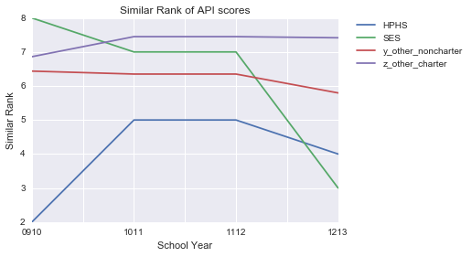

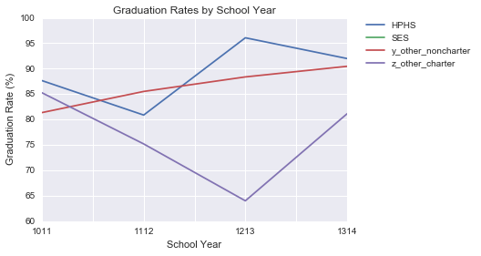

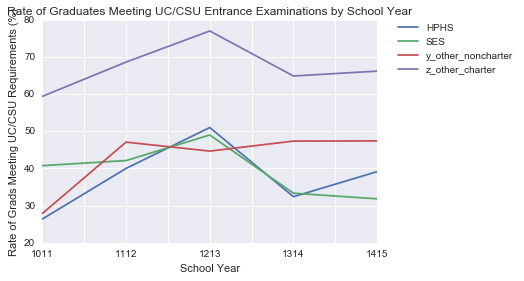

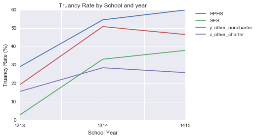

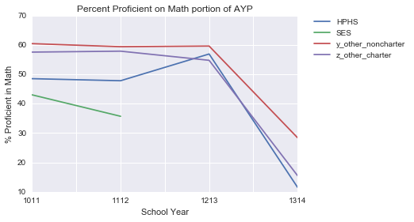

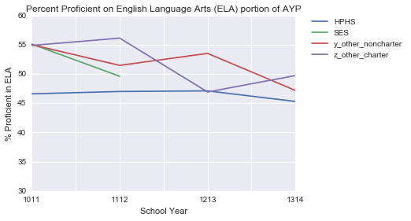

```python
# Pivot dataset
def plot_lines(df, y_variable, title, xlabel, ylabel):
    plot_df = df.loc[:, ['School_Category', 'Year', y_variable]]
    pivot = plot_df.pivot(index = 'Year', columns = 'School_Category', values = y_variable)
    pivot.plot()

    plt.legend(bbox_to_anchor=(1.05, 1), loc=2, borderaxespad=0.)
        #Reference: http://matplotlib.org/users/legend_guide.html

    plt.title(title)
    plt.ylabel(ylabel)
    plt.xlabel(xlabel)

    #plt.gca().set_ylim(top=1)
        # Reference: http://stackoverflow.com/questions/11744990/
        # how-to-set-auto-for-upper-limit-but-keep-a-fixed-lower-limit-with-matplotlib
    return

def subset_by_years(df, yearlist):
    new_df = pd.DataFrame()
    for year in yearlist:
        yr_df = df.loc[df.Year == year]
        new_df = new_df.append(yr_df)
    return new_df

# Make all percentages rates for plotting only
scusd_plot = scusd_ctgy
scusd_plot['Graduate_rate'] = scusd_ctgy['Graduate_rate']* 100
scusd_plot['UC_rate'] = scusd_ctgy['UC_rate']* 100
scusd_plot['Truancy Rate'] = scusd_ctgy['Truancy Rate']* 100
scusd_plot['e_pprof'] = scusd_ctgy['e_pprof']* 100
scusd_plot['m_pprof'] = scusd_ctgy['m_pprof']* 100
#scusd_plot

# Year subsets
sim_years = ['0910','1011','1112','1213']
ten_14 = ['1011', '1112','1213','1314']
ten_15 = ['1011', '1112','1213','1314', '1415']
eleven_15 = ['1112','1213','1314', '1415']
twelve_15 = ['1213','1314', '1415']

# Creating a dataset for simranks only to extrapolate 1112 data by averaging 1011 and 1213.
sim_years = ['0910','1011','1112','1213']
scusd_sim1 = scusd_ctgy.sort_values(['School_Category','Year'])
scusd_sim2 = subset_by_years(scusd_sim1, sim_years)
scusd_sim2 = scusd_sim2.sort_values(['School_Category','Year'])
scusd_sim3 = scusd_sim2.loc[:,['School_Category','Year','sim_rank']]
scusd_sim3 = scusd_sim3.sort_values(['School_Category','Year'])
scusd_sim4 = scusd_sim3.fillna(method = 'ffill')
    # Reference: http://stackoverflow.com/questions/27905295/how-to-replace-nans-by-preceding-values-in-pandas-dataframe
    # Using interpolate for missing data (http://pandas.pydata.org/pandas-docs/stable/missing_data.html)
        # Didn't use that because it seemed to really take liberties with the data!

# Plots of each
sim_rank_plot = plot_lines(scusd_sim4,
                           'sim_rank', 'Similar Rank of API scores', 'School Year', 'Similar Rank')

grad_plot = plot_lines(subset_by_years(scusd_plot, ten_14),
                       'Graduate_rate', 'Graduation Rates by School Year',  "School Year", ' Graduation Rate (%)')

UCgrad_plot = plot_lines(subset_by_years(scusd_plot, ten_15),
                         'UC_rate', 'Rate of Graduates Meeting UC/CSU Entrance Examinations by School Year',
                         'School Year', 'Rate of Grads Meeting UC/CSU Requirements (%)')

truancy_plot = plot_lines(subset_by_years(scusd_plot, twelve_15),
                          'Truancy Rate', 'Truancy Rate by School and year', 'School Year', 'Truancy Rate (%)')

math_plot = plot_lines(subset_by_years(scusd_plot, ten_14),
                       'm_pprof', 'Percent Proficient on Math portion of AYP', 'School Year', '% Proficient in Math')

ela_plot = plot_lines(subset_by_years(scusd_plot, ten_14),
                      'e_pprof', 'Percent Proficient on English Language Arts (ELA) portion of AYP',
                      'School Year', '% Proficient in ELA')
```

*Note*:

- Similar Rank is only reported for school years '09-'10, '10-11, and '12-13. The value included in chart for school year '11-12 is the reported score for school year '10-11.
- School of Engineering & Sciences graduate rate is only reported for school year '10-11, at a rate of 90%.

```python
# Plot formula for all schools
def plot_lines_allschls(df, y_variable, title, xlabel, ylabel):
    plot_df = df.loc[:, ['School', 'year', y_variable]]

    # Drop rows with NA in year column, doesn't work for this data.
        # Some schools in SCUSD have no data for any graduate rates, they're dropped. (REASSESS IF I WANT TO DO THAT.)
    plot_df = plot_df.dropna(subset = ['year'])

    pivot = plot_df.pivot(index = 'year', columns = 'School', values = y_variable)
    pivot.plot()

    plt.legend(bbox_to_anchor=(1.05, 1), loc=2, borderaxespad=0.)
        #Reference: http://matplotlib.org/users/legend_guide.html

    plt.title(title)
    plt.ylabel(ylabel)
    plt.xlabel(xlabel)
    plt.legend(bbox_to_anchor=(1.05, 1), loc=2, borderaxespad=0.)
    plt.show()
    #plt.gca().set_ylim(top=1)
        # Reference: http://stackoverflow.com/questions/11744990/
        # how-to-set-auto-for-upper-limit-but-keep-a-fixed-lower-limit-with-matplotlib
    return

#gradsallschools = plot_lines_allschls(scusd, 'gradrate', 'Graduate Rates by SCUSD High Schools',
 #                     'School Year', 'Graduate Rate')
```

## Outcomes by SCUSD High Schools

### 3 Year Weighted Average of Most Recent Data

```python
# Subset scusd into 12-15 (1213, 1314, 1415) and 11-14 (1112, 1213, 1314)
scusd13_15 = scusd.loc[((scusd.year == '1213') | (scusd.year == '1314') | (scusd.year == '1415'))]
scusd12_14 = scusd.loc[((scusd.year == '1112') | (scusd.year == '1213') | (scusd.year == '1314'))]
scusd11_13 = scusd.loc[((scusd.year == '1011') | (scusd.year == '1112') | (scusd.year == '1213'))]
scusd10_13 = scusd.loc[((scusd.year == '0910') | (scusd.year == '1011') | (scusd.year == '1213'))]

## Functions to create grouped datasets and plots

# Create subset of dataset by school year
def subsetbycds(df, cds):
    newdf = df.loc[df.cds == cds]
    return newdf

# Create weighted averages for wavg columns - if there are no values for a year in one column, return Nan
    # Same formula as above
def wavg(df, data_col, weight_col):
    try:
        d = df[data_col]
        w = df[weight_col]
        return (d * w).sum() / w.sum()
    except ZeroDivisionError:
        return float('nan')
#https://docs.python.org/2/tutorial/errors.html

# Create weighted average datasets for sets of results by year.
def create_wavg_dataset1(cds):
    # First apply weighted averages to school in 12-15 dataset
    df1315 = subsetbycds(scusd13_15, cds)
    grouped1 = df1315.groupby(df1315.cds, as_index = False)

    ## 13-15 Data - grads, school, school category, total students, grades served, UC rate, truancy rate
    new_df = grouped1['GRADS'].mean()
    new_df['School'] = df1315.iloc[0,1]
    new_df['School_Category'] = df1315.iloc[0,4]
    new_df['Total Students (9-12)'] = df1315['high_tot'].mean()
    new_df['Grades Served'] = df1315.iloc[0,2]
    new_df['UC_rate'] = grouped1.apply(wavg, 'UC_rate', 'GRADS')
    new_df['Truancy Rate'] = grouped1.apply(wavg, 'Truancy Rate', 'ENR_TOTAL')

    ## 12-14 Data - graduate rate, ELA/Math % proficient
    df1214 = subsetbycds(scusd12_14, cds)
    grouped2 = df1214.groupby(df1214.cds, as_index = False)

    new_df['Graduate_rate'] = grouped2.apply(wavg, 'gradrate', 'GR_12')
    new_df['e_pprof'] = grouped2.apply(wavg, 'e_pprof', 'e_val')
    new_df['e_val'] = df1214.e_val.mean()
    new_df['m_pprof'] = grouped2.apply(wavg, 'm_pprof', 'm_val')
    new_df['m_val'] = df1214.m_val.mean()

    ## 10-13 Data - similar/state api rank
    df1013 = subsetbycds(scusd10_13, cds)
    grouped3 = df1013.groupby(df1013.cds, as_index = False)

    new_df['sim_rank'] = grouped3.apply(wavg, 'sim_rank', 'ENR_TOTAL')
    new_df['st_rank'] = grouped3.apply(wavg, 'st_rank', 'ENR_TOTAL')

    # Rename Other Schools
    #new_df.School_Category.replace(to_replace = 'z_other_charter', value = 'Other Charter Schools', inplace = True)
    #new_df.School_Category.replace(to_replace = 'y_other_noncharter', value = 'Other Non-charter Schools', inplace = True)

    # Rename column
    new_df.rename(columns = {'GRADS':'Graduates'}, inplace = True)

    # Reorder columns
    #cols = ['cds','Graduates', 'School_Category', 'Grades Served',
     #       'UC_rate', 'Truancy Rate', 'Graduate_rate', 'e_pprof', 'm_pprof']
    #cols = ['cds','School', 'School_Category','Grades Served', 'Total Students','e_pprof', 'm_pprof', 'Graduates',
     #       'Graduate_rate', 'UC_rate', 'Truancy Rate']
    #new_df = new_df[cols]

    #Brute force fixing for graduate_rate, truancy, and sim/state rank data to replace wrong 0s with Nans.
    new_df.Graduate_rate.replace(to_replace = 0, value = float('nan'), inplace = True)
    new_df['Truancy Rate'].replace(to_replace = 0, value = float('nan'), inplace = True)
    new_df.sim_rank.replace(to_replace = 0, value = float('nan'), inplace = True)
    new_df.st_rank.replace(to_replace = 0, value = float('nan'), inplace = True)

    return new_df

def create_dataset(cds_list):
    df = pd.DataFrame()
    for schl in cds_list:
        schldf = create_wavg_dataset1(schl)
        df = df.append(schldf)
    return df
```

```python
# Create datasets from above formulas
scusd1 = create_dataset(list(scusd12_14.cds.unique()))
list(scusd1.columns)

# Add API11to14 - already a weighted average result so adding later.
apiwavg = api11to14.loc[:,['cds','avg_w']]
apiwavg = apiwavg.rename(columns = {'avg_w':'API_11to14'})
apiwavg.API_11to14 = pd.to_numeric(apiwavg.API_11to14, errors = 'coerce')
scusd2 = scusd1.merge(apiwavg, on = 'cds', how = 'left')
scusd2

# Add charter status column
scusd2['Charter Status'] = np.where(((scusd2.School_Category == 'HPHS') |
                             (scusd2.School_Category == 'SES') |
                             (scusd2.School_Category == 'y_other_noncharter')), 'Non-charter', 'Charter')


#Rename and rearrange columns for display - fix this!
scusd_disp = scusd2.loc[:,['cds','School', 'Charter Status','Grades Served','Total Students (9-12)',
                 'sim_rank','st_rank','API_11to14', 'e_pprof','m_pprof', 'Graduates',
                  'Graduate_rate', 'UC_rate','Truancy Rate']]

# Convert relevant columns into %
def makepercent(df, column):
    df[column] = pd.Series(["{0:.0f}%".format(val * 100)
                                                        for val in df[column]],
                                                       index = df.index)
# Transform to percentages
makepercent(scusd_disp, 'e_pprof')
makepercent(scusd_disp, 'm_pprof')
makepercent(scusd_disp, 'Graduate_rate')
makepercent(scusd_disp, 'UC_rate')
makepercent(scusd_disp, 'Truancy Rate')

# Round non-percents
scusd_disp = scusd_disp.round({"Total Students (9-12)": 0, "sim_rank": 0, "st_rank": 0})

# Rename columns
scusd_disp1 = scusd_disp.rename(columns = {'sim_rank':"Similar Rank ('10-13)", 'st_rank':"State Rank ('10-13)",
                        'API_11to14':"API ('11-13)",'e_pprof':"ELA % Proficient ('12-14)",
                                  'Graduate_rate':"Graduate Rate ('12-14)",
                        'm_pprof': "Math % Proficient ('12-14)", 'UC_rate':"Rate of Grads Meeting UC/CSU Reqmt ('13-15)",
                                 'Truancy Rate':"Truancy Rate ('13-15)"})

# Select columns to display
display_cols = ['School', 'Charter Status', 'Grades Served', "Total Students (9-12)","Similar Rank ('10-13)",
                "State Rank ('10-13)", "API ('11-13)","ELA % Proficient ('12-14)", "Math % Proficient ('12-14)",
                "Graduate Rate ('12-14)","Rate of Grads Meeting UC/CSU Reqmt ('13-15)", "Truancy Rate ('13-15)"]

fancydisplay(scusd_disp1.loc[:,display_cols])

# SPOTCHECKED = YES
```

| School | Charter Status | Grades Served | Total Students (9-12) | Similar Rank ('10-13) | State Rank ('10-13) | API ('11-13) | ELA % Proficient ('12-14) | Math % Proficient ('12-14) | Graduate Rate ('12-14) | Rate of Grads Meeting UC/CSU Reqmt ('13-15) | Truancy Rate ('13-15) |
| --- | --- | --- | --- | --- | --- | --- | --- | --- | --- | --- | --- |
| Arthur A. Benjamin Health Professions High | Non-charter | 9-12 | 264 | 4 | 3 | 687 | 46% | 39% | 90% | 40% | 46% |
| School of Engineering & Sciences | Non-charter | 7-12 | 237 | 6 | 6 | 777 | 42% | 33% | nan% | 40% | 25% |
| C. K. McClatchy High | Non-charter | 9-12 | 2267 | 3 | 6 | 762 | 55% | 50% | 89% | 50% | 34% |
| Hiram W. Johnson High | Non-charter | 9-12 | 1475 | 8 | 3 | 690 | 29% | 36% | 78% | 22% | 45% |
| John F. Kennedy High | Non-charter | 9-12 | 2095 | 5 | 5 | 756 | 56% | 52% | 90% | 46% | 35% |
| Luther Burbank High | Non-charter | 9-12 | 1702 | 7 | 2 | 674 | 37% | 40% | 88% | 49% | 55% |
| Rosemont High | Non-charter | 9-12 | 1388 | 7 | 4 | 733 | 46% | 46% | 89% | 34% | 42% |
| West Campus | Non-charter | 9-12 | 858 | 10 | 10 | 904 | 92% | 89% | 99% | 81% | 12% |
| George Washington Carver School of Arts and Sc... | Charter | 9-12 | 294 | 6 | 6 | 774 | 66% | 50% | 42% | 19% | 22% |
| New Technology High | Charter | 9-12 | 286 | 6 | 3 | 716 | 42% | 40% | 30% | 87% | 41% |
| Sacramento Charter High | Charter | 9-12 | 928 | 10 | 7 | 784 | 50% | 44% | 91% | 96% | 26% |
| The MET | Charter | 9-12 | 310 | 1 | 3 | 706 | 49% | 37% | 88% | 31% | 2% |

*School*: Inlcludes all schools categorized as high school in Sacramento City Unified School District, excluding American Legion High (Continuation), Capital City Independent Study. These schools are excluded because they serve different target populations and their test results differ substantially from those of the other high schools.

*Charter Status*: Denotes status of school as either public non-charter or public charter.

*Grades Served*: Represents grade span served, lowest and highest grade of student enrollment. (Data source: pubschls)

*Total Students (9-12)*: Total number of enrolled students from grades 9-12, averaged for school years 2012-13 through 2014-15. (Data source: filesenrl)

*Similar Rank ('10-13)* & *Statewide Rank ('10-13)*: Schools are ranked in ten categories of equal size, called deciles, from 10 (highest) to 1 (lowest). Statewide rank compares API to APIs of all other schools statewide of same type (elementary, middle, or high school). Similar schools rank compares API to APIs of 100 other schools of same type that have similar opportunities and challenges.

Data presented is weighted averaged from API results of years 2009-10, 2010-11, and 2012-13 (no data for 2011-12), weighted by total enrollment. Schools are no longer taking the API exam nor being ranked, so more recent data is not available. (Data source: api) [further reference: https://www.ed-data.k12.ca.us/Pages/UnderstandingTheAPI.aspx] **Includes data from middle school

*API ('11-'13)*: Academic Performance Index (API) measures academic performance and growth of schools on a variety of academic measures. Established by Public Schools Accountability Act (PSAA), landmark state law passed in 1999 that created new academic accountability system for kindergarten through grade twelve public education in CA. API is single number from 200 to 1000; state has set 800 as API target for all schools to meet. API is calculated by converting a student's performance on statewide assessments across multiple content areas into points on the API scale. The following tests are included in assessment:

- California Standards Tests (CSTs) - grades 2-11
- California Modified Assessment (CMA) - grades 3-11
- California Alternative Performance Assessment (CAPA) - grades 2-11
- California High School Exit Examination (CAHSEE) - grade 10 (11, 12 if not passed first) The value reported is the average weighted 3 year score for the school, for results in 2011, 2012, and 2013. California is currently revising their tests so no API results were reported for 2014 or 2015. (Data source: API3yr_14)

Since the API is based on several tests that are conducted from grades 2-11, this score does not only reflect performance of high school students. Thus, the score for the School of Engineering and Science (the only 7-12 school) is also reflecting performance of 7-8 graders, while the score for other schools reflects only students in grades 9-12.

*ELA % Proficient* & *Math % Proficient*: Results from Adequate Yearly Progress (AYP report). AYP is a statewide accountability system mandated by the No Child Left Behind Act of 2001 to ensure that all schools and districts make Adequate Yearly Progress. The test includes the English language arts/Literacy (ELA) component and mathematics. The AYP report reflects school's performance on following tests, which are part of CA's 2013-14 statewide testing administration:

- Standardized Testing and Reporting (STAR) Program - (grades 2-11) - Students take tests in math, reading, writing, science, and history. The program includes four tests: the California Standards Tests, the California Modified Assessment, the California Alternate Performance Assessment, and the Standards-based Tests in Spanish. The STAR program ended on July 1, 2013, replaced by California Assessment of Student Performance and Progress (CAASPP) System.
- California High School Exit Examination (CAHSEE) in ELA and mathematics - (grade 10) - Passing score for math is approximately 55% of items correct or scale score of 350; for ELA passing score is approximately 60% of items correct or scale score of 350. Now gone. [http://www.cde.ca.gov/ta/tg/hs/cefcahsee.asp]
- California Alternate Performance Assessment (CAPA) in ELA and mathematics (grade 10) - included to meet requirements of Individuals with Disabilities Education Act (IDEA) and the Elementary and Secondary Education Act (ESEA), demonstrate that all students are included in statewide assessment and accountability system. CAPA is alternate assessment for students taht cannot take part in general statewide assessment programs. http://www.cde.ca.gov/ta/ac/ay/cefayp.asp
- CAASPP - new standardized test. SBAC, that's the company that's doing it. grade 3-8, 11, to double check.

Column values represent the weighted average value of the percentage of students that were deemed proficient or passing in the ELA and math portions of the CAHSEE from the school year results of 2011-12, 2012-13, and 2013-14, weighted by the number of studetns taking the tests. (Data source: AYP)

The AYP is also based on several tests that are conducted from grades 2-11, this score does not only reflect performance of high school students. Thus, the score for the School of Engineering and Science (the only 7-12 school) is also reflecting performance of 7-8 graders, while the score for other schools reflects only students in grades 9-12.

*Total Graduates ('13-15)*: Average number of twelfth grade graduates for the 2012-13, 2013-14, and 2014-15 school years. This data includes summer graduates and does not include students with high school equivalencies (i.e., General Educational Development (GED) test or California High School Proficiency Examination (CHSPE). (Data source: filesgrads)

*Graduate Rate ('12-14)*: Weighted average graduation rates for the classes of 2011-12, 2012-13, and 2013-14 as reported in AYP, weighted by number of 12th grade students. No data listed for School of Engineering & Sciences. (Data source: AYP)

*% of Grads meeting UC/CSU Rqmts ('13-15)*: Weighted average rate of twelfth-grade graduates for 2014-2015 school year who also completed all courses required for entry into the University of California (UC) and/or California State University (CSU) with a grade "C" or better for the school years of 2012-13, 2013-14, and 2014-15. Data is weighted by number of graduates. This data includes summer graduates and does not include students with high school equivalencies (i.e., GED or CHSPE). (Data source: filesgrads)

*Truancy Rate ('13-15)*: Truancy is defined by the California Department of Education as a student missing more than 30 minutes of instruction without an excuse three times during the school year. The above table includes the average weighted percent of truant students in the school as a whole during the school years of 2012-13, 2013-14, and 2014-15, weighted by total school enrollment. (Data source: Truancy)

**Note: Similar Rank, State Rank, API, ELA % Proficient, Math % Proficient, and Truancy Rate all represent data for the school as a whole, data is not disaggregated by grade. Therefore results for the School of Engineering and Sciences reflect middle school performance as well as high school. All other schools serve high school grade levels only, thus their test results reflect only high school performance.

**Only Graduate Rate ('12-14) and Rate of Grads Meeting UC/CSU Reqmt ('13-15) reflect exclusively high school results.

## SCUSD School Outcomes by HPHS, SES, Other SCUSD Non-Charter, and Other SCUSD Non-Charter High Schools

### 3 Year Weighted Average of Most Recent Data

```python
# Create weighted average dataset
def create_wavg_dataset2(df):
    grouped = df.groupby(df.School_Category, as_index = False)

    ## ADD TO THIS WHEN ADDING ADDITIONAL DATA COLUMNS
    new_df = grouped["Total Students (9-12)"].mean()
    new_df["Similar Rank ('10-13)"] = grouped.apply(wavg, 'sim_rank', 'Total Students (9-12)')
    new_df["State Rank ('10-13)"] = grouped.apply(wavg, 'st_rank', 'Total Students (9-12)')
    new_df["API ('11-13)"] = grouped.apply(wavg, "API_11to14", 'Total Students (9-12)')
    new_df["ELA % Proficient ('12-14)"] = grouped.apply(wavg, "e_pprof", 'e_val')
    new_df["Math % Proficient ('12-14)"] = grouped.apply(wavg, "m_pprof", 'm_val')
    new_df["Graduate Rate ('12-14)"] = grouped.apply(wavg, "Graduate_rate", 'Total Students (9-12)')
    new_df["Rate of Grads meeting UC/CSU Reqmts ('13-15)"] = grouped.apply(wavg, 'UC_rate', 'Graduates')
    new_df["Truancy Rate ('13-15)"] = grouped.apply(wavg, "Truancy Rate", 'Total Students (9-12)')


    #Brute force fixing for graduate_rate data to replace wrong 0s with Nans.
    new_df["Graduate Rate ('12-14)"].replace(to_replace = 0, value = float('nan'), inplace = True)
    new_df["Similar Rank ('10-13)"].replace(to_replace = 0, value = float('nan'), inplace = True)
    new_df["State Rank ('10-13)"].replace(to_replace = 0, value = float('nan'), inplace = True)
    new_df["Truancy Rate ('13-15)"].replace(to_replace = 0, value = float('nan'), inplace = True)


    # Rename Other Schools
    new_df.School_Category.replace(to_replace = 'z_other_charter', value = 'Other Charter Schools', inplace = True)
    new_df.School_Category.replace(to_replace = 'y_other_noncharter', value = 'Other Non-charter Schools', inplace = True)

    # Round column values
    new_df = new_df.round({"API ('11-13)": 0, "Similar Rank ('10-13)": 0, "State Rank ('10-13)":0,
                           'Total Students (9-12)':0})

    # Make percent other columns for display
    makepercent(new_df, "Graduate Rate ('12-14)")
    makepercent(new_df, "ELA % Proficient ('12-14)")
    makepercent(new_df, "Math % Proficient ('12-14)")
    makepercent(new_df, "Rate of Grads meeting UC/CSU Reqmts ('13-15)")
    makepercent(new_df, "Truancy Rate ('13-15)")

    # Rename column
    #new_df.rename(columns = {'Total Students':"Total Students ('12-15)"}, inplace = True)

    # Reorder columns
    #cols = ['School_Category','Year', 'Graduates', 'Graduate_rate', 'UC_rate', 'Truancy Rate', 'e_pprof', 'm_pprof']
    #new_df = new_df[cols]

    return new_df

scusd_grp1 = create_wavg_dataset2(scusd2)

scusd_grp_disp1 = scusd_grp1

fancydisplay(scusd_grp_disp1)

#SPOTCHECKED = YES
```

| School_Category | Total Students (9-12) | Similar Rank ('10-13) | State Rank ('10-13) | API ('11-13) | ELA % Proficient ('12-14) | Math % Proficient ('12-14) | Graduate Rate ('12-14) | Rate of Grads meeting UC/CSU Reqmts ('13-15) | Truancy Rate ('13-15) |
| --- | --- | --- | --- | --- | --- | --- | --- | --- | --- |
| HPHS | 264 | 4 | 3 | 687 | 46% | 39% | 90% | 40% | 46% |
| SES | 237 | 6 | 6 | 777 | 42% | 33% | nan% | 40% | 25% |
| Other Non-charter Schools | 1631 | 6 | 5 | 743 | 51% | 50% | 88% | 46% | 39% |
| Other Charter Schools | 454 | 7 | 6 | 758 | 51% | 43% | 73% | 69% | 23% |

*Other Non-charter Schools* and *Other Charter Schools* includes all other active Sacramento high schools, distinguished by charter status.

All values reported for *Other Non-charter Schools* and *Other Charter Schools* are weighted averages among schools, for the school years listed in title. 'Total Students (9-12)' is the mean number of students in grades 9-12 from school years 2012-13, 2013-14, and 2014-15.

All schools included in *Other Non-charter Schools* and *Other Charter Schools* serve grades 9-12 only.

**Note: Similar Rank, State Rank, API, ELA % Proficient, Math % Proficient, and Truancy Rate all represent data for the school as a whole, data is not disaggregated by grade. Therefore results for the School of Engineering and Sciences reflect middle school performance as well as high school. All other schools serve high school grade levels only, thus their test results reflect only high school performance.

**Only 'Graduate Rate' and 'Rate of Grads meeting UC/CSU Reqmts' represents high school performance only.

## SCUSD High School Performance Comparison Charts - API and AYP Results by School

```python
#Bar plot comparisons
def barplot1var(df, plot_title, colname, y_axis_title):
    sns.set_context(rc={"figure.figsize": (8, 4)})
    sns.set_style("whitegrid")
    #sns.set_palette(sns.color_palette("Set2", 10))

    df[colname] = pd.to_numeric(df[colname], errors = 'coerce')

    plot = sns.barplot(x = 'School_Category', y = colname, data = df)
    for item in plot.get_xticklabels():
        item.set_rotation(90)
    plot.set_title(plot_title)
    plot.set(ylabel = y_axis_title)
    #plot.set_xticklabels(df.index,rotation=90)
```

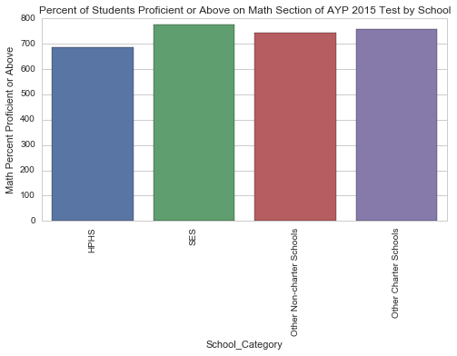

```python
API_grp = barplot1var(scusd_grp1, "API 3yr Average Weighted Score by School", "API ('11-13)",
                      "API 3yr Average Weighted Value")

ELA_grouped = barplot1var(scusd_grp1, "Percent of Students Proficient or Above on ELA Section of AYP 2015 Test by School",
            "ELA % Proficient ('12-14)", "ELA Percent Proficient or Above")

math_all = barplot1var(scusd_grp1, "Percent of Students Proficient or Above on Math Section of AYP 2015 Test by School",
        "Math % Proficient ('12-14)", "Math Percent Proficient or Above")
```

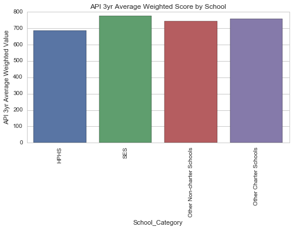

```python
API_grp = barplot1var(scusd_grp1, "API 3yr Average Weighted Score by School", "API ('11-13)",
                      "API 3yr Average Weighted Value")
```

# Deliverable 2: Comparing 6/7-12 Schools and High Schools across California, Indianapolis, Tulsa, and Cincinatti

1. Frequency and distribution of 7-12 model in California, Indianapolis, Tulsa, and Cincinatti
   1. Total # of 7-12 schools, and % of high schools that are 7-12 or 6-12 for following sets:
      1. All schools
      2. Public schools
      3. Public non-charter schools
   2. Among schools with populations of similar demographic - applied with 'Similar Rank' for API score
2. Assessment and where applicable performance of 7-12 schools in California, Indianapolis, Tulsa, and Cincinatti

```python
# Create clear distinction between charter and non-charter schools
#Find and replace value in dataframe - charter column Y and N for charter/non-charter
pubschls['Charter'].replace(to_replace = 'Y', value = 'Charter', inplace = True)
pubschls['Charter'].replace(to_replace = 'N', value = 'Non-charter', inplace = True)

# Rename cds code
pubschls = pubschls.rename(columns = {'CDSCode':'cds'})

# Subset California public schools to include only active schools
activeschls = pubschls[pubschls.StatusType == 'Active']
#print len(activeschls)
```

```python
# Create datasets by grades served (using GSserved)
    #Action type: subset dataframe by value in column
sixup_served = activeschls.loc[activeschls['GSserved'] == '6-12']
sevenup_served = activeschls.loc[activeschls['GSserved'] == '7-12']
sixsevup_served = sixup_served.append(sevenup_served)
nineup_served = activeschls.loc[activeschls['GSserved'] == '9-12']
sixtohigh_served = sixsevup_served.append(nineup_served)

#sixtohigh_served.Charter.unique()
#sixtohigh is all schools serving 6-12, 7-12, or 9-12
```

```python
# Create datasets by grades offered (using GSoffered)
    #Action type: subset dataframe by value in column
sixup_offered = activeschls.loc[activeschls['GSoffered'] == '6-12']
sevenup_offered = activeschls.loc[activeschls['GSoffered'] == '7-12']
sixsevup_offered = sixup_offered.append(sevenup_offered)
sixtohigh_offered = sixsevup_offered.append(activeschls.loc[activeschls['GSoffered'] == '9-12'])
```

```python
## California: Compare Grades Served to Grades Offered - ranges 6-12, 7-12, and 9-12

#Group by grade range of schools, using grades served
sixtohigh_group = sixtohigh_served.groupby(sixtohigh_served['GSserved'], as_index = False)
sixtohigh = sixtohigh_group['cds'].count()
sixtohigh.rename(columns={'GSserved':'Grades', 'cds':'Schools Serving Grades'}, inplace=True)

#Group by grade range of schools, using grades offered
sixtohighoff_group = sixtohigh_offered.groupby(sixtohigh_offered['GSoffered'], as_index = False)

#Merge datasets to have one table with grades served and grades offered
sixtohigh['Schools Offering Grades'] = sixtohighoff_group['cds'].count()['cds']

#Add totals row
sixtohigh_tot = sixtohigh.append(sixtohigh.sum(), ignore_index = True)
sixtohigh_tot['Grades'].replace(to_replace = '6-127-129-12', value = 'All', inplace = True)

#Add percent column
sixtohigh_tot['Percent of Schools Serving All Grades Offered'] = (sixtohigh_tot['Schools Serving Grades']/
                                                                  sixtohigh_tot['Schools Offering Grades'])
    #convert to percentage
makepercent(sixtohigh_tot, 'Percent of Schools Serving All Grades Offered')

#fancydisplay(sixtohigh_tot)
```

```python
#Functions to create Schools by Grade Range and Charter/Non-charter Status table
def addgradescolumn(grade_data, colname):
    group = grade_data.groupby(grade_data['Charter'], as_index = False)
    charter[colname] = group['cds'].count()['cds']
    return

def addpercentcolumn(coltodivide, colname):
    charter_tot[colname] = charter_tot[coltodivide]/charter_tot['Total Schools*']
    charter_tot[colname] = pd.Series(["{0:.2f}%".format(val * 100) for val in charter_tot[colname]], index = charter_tot.index)
    return

def apply_add_column(list_o_lists, function):
    for i in list_o_lists:
        function(i[0], i[1])
    return
```

# California

## California (Statewide): Public Schools by Grade Range and Charter/Non-Charter Type

```python
#Group by school type - charter or non-charter
charter_group = sixtohigh_served.groupby(sixtohigh_served['Charter'], as_index = False)
charter = charter_group['cds'].count()
charter.rename(columns={'Charter': 'Charter Status', 'cds':'Total Schools*',}, inplace=True)

#Add columns for grade ranges in question
apply_add_column([[sixup_served, 'Total 6-12 Schools'],[sevenup_served, 'Total 7-12 Schools'],
                  [sixsevup_served, 'Total 6/7-12 Schools'], [nineup_served, 'Total 9-12 Schools']], addgradescolumn)

#Add totals row
charter_tot = charter.append(charter.sum(), ignore_index = True)
charter_tot['Charter Status'].replace(to_replace = 'CharterNon-charter', value = 'All', inplace = True)

#Add percentage columns for each grade range
apply_add_column([['Total 6-12 Schools', '% 6-12 of Total'], ['Total 7-12 Schools', '% 7-12 of Total'], ['Total 6/7-12 Schools', '% 6/7-12 of Total'],
                 ['Total 9-12 Schools', '% 9-12 of Total']], addpercentcolumn)

#Rearrange columns
cols = ['Charter Status', 'Total 6-12 Schools', '% 6-12 of Total', 'Total 7-12 Schools',
        '% 7-12 of Total', 'Total 6/7-12 Schools', '% 6/7-12 of Total', 'Total 9-12 Schools',
        '% 9-12 of Total', 'Total Schools*']
charter_tot = charter_tot[cols]

#Display chart
fancydisplay(charter_tot)
```

| Charter Status | Total 6-12 Schools | % 6-12 of Total | Total 7-12 Schools | % 7-12 of Total | Total 6/7-12 Schools | % 6/7-12 of Total | Total 9-12 Schools | % 9-12 of Total | Total Schools* |
| --- | --- | --- | --- | --- | --- | --- | --- | --- | --- |
| Charter | 57 | 20.07% | 47 | 16.55% | 104 | 36.62% | 180 | 63.38% | 284 |
| Non-charter | 30 | 2.12% | 124 | 8.77% | 154 | 10.89% | 1260 | 89.11% | 1414 |
| All | 87 | 5.12% | 171 | 10.07% | 258 | 15.19% | 1440 | 84.81% | 1698 |

**Total schools* refers to all California public schools with grade ranges of either 6-12, 7-12, or 9-12.

*All* is the sum of charter and non/charter public schools in stated grade ranges.

Grade ranges represent grades served by the school, i.e. students are enrolled. This differs in some cases from the grade range the school offers.

## California (Statewide): Performance of Schools by Grade Range Served

```python
#California: Performance of Public, Non-charter 6/7-12 Schools compared to High Schools

#Include non-charter schools only [If I change my mind, delete these lines and have next formula call to sixtohigh_served]
ca_sixup = sixtohigh_served.loc[sixtohigh_served['Charter'] == 'Non-charter']


#list(ca_sixup.columns)

# Include relevant columns only
ca_cols =['cds', 'County', 'District', 'School','GSserved','Charter']
ca_sixup1 = ca_sixup.loc[:, ca_cols]

# Merge with data by year for all CA schools
ca_sixup2 = ca_sixup1.merge(results5, how = 'left', on = 'cds')

#ca_sixup2.loc[ca_sixup2.County == 'Alameda'
#len(ca_sixup2.ENR_TOTAL.unique())
#len(ca_sixup2)

# Check type of columns in dataframe
#ca_sixup2.dtypes
```

```python
## Create weighted average most recent results for all CA non-charter schools

# Subset ca_sixup into 13-15 (1213, 1314, 1415), 12-14 (1112, 1213, 1314), and 11-13 (1011, 1112, 1213)
ca13_15 = ca_sixup2.loc[((ca_sixup2.year == '1213') | (ca_sixup2.year == '1314') | (ca_sixup2.year == '1415'))]
ca12_14 = ca_sixup2.loc[((ca_sixup2.year == '1112') | (ca_sixup2.year == '1213') | (ca_sixup2.year == '1314'))]
ca11_13 = ca_sixup2.loc[((ca_sixup2.year == '1011') | (ca_sixup2.year == '1112') | (ca_sixup2.year == '1213'))]
ca10_13 = ca_sixup2.loc[((ca_sixup2.year == '0910') | (ca_sixup2.year == '1011') | (ca_sixup2.year == '1213'))]

## Functions to create grouped datasets and plots

# Create subset of dataset by school year
def subsetbycds1(df, cds):
    newdf = df.loc[df.cds == cds]
    return newdf

# Create weighted averages for wavg columns - if there are no values for a year in one column, return Nan
def wavg(df, data_col, weight_col):
    try:
        d = df[data_col]
        w = df[weight_col]
        return (d * w).sum() / w.sum()
    except ZeroDivisionError:
        return float('nan')
#https://docs.python.org/2/tutorial/errors.html

# Create weighted average dataset by school
def create_wavg_dataset3(cds):

    ## 13-15 Data - grads, school, school category, total students, grades served, UC rate, truancy rate
    df1315 = subsetbycds(ca13_15, cds)
    grouped1 = df1315.groupby(df1315.cds, as_index = False)

    new_df = grouped1['ENR_TOTAL'].mean()
    new_df['GSserved'] = df1315.iloc[1,4]
    new_df['UC_rate'] = grouped1.apply(wavg, 'UC_rate', 'GRADS')
    new_df['Truancy'] = grouped1.apply(wavg, 'Truancy Rate', 'ENR_TOTAL')
    new_df = new_df.merge(grouped1['GRADS'].mean())

    ## 12-14 Data - graduate rate and number of grade 12 students
    df1214 = subsetbycds(ca12_14, cds)
    grouped2 = df1214.groupby(df1214.cds, as_index = False)
    new_df['Graduate_rate'] = grouped2.apply(wavg, 'gradrate', 'GR_12')
    new_df = new_df.merge(grouped2['GR_12'].mean())

    ## 10-13 Data - similar/state api rank
    df1013 = subsetbycds(ca10_13, cds)
    grouped3 = df1013.groupby(df1013.cds, as_index = False)

    new_df['sim_rank'] = grouped3.apply(wavg, 'sim_rank', 'ENR_TOTAL')
    new_df['st_rank'] = grouped3.apply(wavg, 'st_rank', 'ENR_TOTAL')

    # Rename column
    new_df.rename(columns = {'ENR_TOTAL':'Average Total Students'}, inplace = True)

    #Brute force fixing for graduate_rate, truancy, and sim/state rank data to replace wrong 0s with Nans.
    new_df.Graduate_rate.replace(to_replace = 0, value = float('nan'), inplace = True)
    new_df.Truancy.replace(to_replace = 0, value = float('nan'), inplace = True)
    new_df.sim_rank.replace(to_replace = 0, value = float('nan'), inplace = True)
    new_df.st_rank.replace(to_replace = 0, value = float('nan'), inplace = True)

    return new_df

def create_dataset(cds_list):
    df = pd.DataFrame()
    for schl in cds_list:
        schldf = create_wavg_dataset3(schl)
        df = df.append(schldf)
    return df

# Create full dataset from list of cds in ca12_14, because that has least number of schools included, otherwise run into errors
ca_target1 = create_dataset(list(ca12_14.cds.unique()))
#ca_target1.head()
```

```python
#ca_target1.head()

grouped = ca_target1.groupby(ca_target1.GSserved, as_index = False)

    ## ADD TO THIS WHEN ADDING ADDITIONAL DATA COLUMNS
new_df = grouped["Average Total Students"].mean()
new_df = new_df.merge(grouped['cds'].count())

#new_df
```

```python
## Note: somehow this throws an error - no common columns to merge on if I run this cell immediately following creation
## of previous cell. If I run through the manual grouping and merging first, it works fine.
## So I'll save as html with this run already, but note if it happens again I just have to deconstruct a little.
#MYSTERY

# Create weighted average dataset by grades served.
def create_wavg_dataset4(df):
    grouped = df.groupby(df.GSserved, as_index = False)

    ## ADD TO THIS WHEN ADDING ADDITIONAL DATA COLUMNS
    new_df = grouped["Average Total Students"].mean()
    new_df = new_df.merge(grouped['cds'].count())
    new_df["Graduate Rate ('12-14)"] = grouped.apply(wavg, "Graduate_rate", 'GR_12')
    new_df["Rate of Grads meeting UC/CSU Reqmts ('13-15)"] = grouped.apply(wavg, 'UC_rate', 'GRADS')
    new_df["Truancy Rate ('13-15)"] = grouped.apply(wavg, "Truancy", 'Average Total Students')
    new_df["Similar Rank ('10-13)"] = grouped.apply(wavg, 'sim_rank', 'Average Total Students')

    #Brute force fixing for graduate_rate data to replace wrong 0s with Nans.
    new_df["Graduate Rate ('12-14)"].replace(to_replace = 0, value = float('nan'), inplace = True)
    new_df["Truancy Rate ('13-15)"].replace(to_replace = 0, value = float('nan'), inplace = True)


    # Round column values
    new_df = new_df.round({'Average Total Students':0, "Similar Rank ('10-13)":0})

    # Make percent other columns for display
    makepercent(new_df, "Graduate Rate ('12-14)")
    makepercent(new_df, "Rate of Grads meeting UC/CSU Reqmts ('13-15)")
    makepercent(new_df, "Truancy Rate ('13-15)")

    # Rename column
    new_df.rename(columns = {'GSserved':"Grades Served", 'cds': 'Total Schools'}, inplace = True)

    # Reorder columns
    cols = ['Grades Served', 'Total Schools', 'Average Total Students', "Similar Rank ('10-13)", "Graduate Rate ('12-14)",
            "Rate of Grads meeting UC/CSU Reqmts ('13-15)", "Truancy Rate ('13-15)"]
    new_df = new_df[cols]

    return new_df

# Create final dataset
GSserved_outcomes = create_wavg_dataset4(ca_target1)
fancydisplay(GSserved_outcomes)
```

| Grades Served | Total Schools | Average Total Students | Similar Rank ('10-13) | Graduate Rate ('12-14) | Rate of Grads meeting UC/CSU Reqmts ('13-15) | Truancy Rate ('13-15) |
| --- | --- | --- | --- | --- | --- | --- |
| 6-12 | 29 | 657 | 3 | 52% | 41% | 51% |
| 7-12 | 119 | 346 | 5 | 56% | 37% | 32% |
| 9-12 | 1254 | 1297 | 5 | 89% | 45% | 41% |

Above table demonstrates most recent 3 year weighted average results for schools in California by grade spans served, including 6-12, 7-12, and 9-12. In comparing the numbers of schools in each category to previous table, several schools have been dropped from this analysis due to lack of data.

Data is included for active, public, non-charter schools.

# Indianapolis, Indiana

```python
#Transform excel file into pandas dataframe. Ensure first sheet in excel file has data, first row contains column headings
def excel_to_dataframe1(datafile, indexsheet):
    workbook = xlrd.open_workbook(datafile)
    sheet = workbook.sheet_by_index(indexsheet)
    #Ensure first sheet has the data
    data = [[sheet.cell_value(r, col)
                for col in range(sheet.ncols)]
                    for r in range(sheet.nrows)]
    headers = data.pop(0)
    df = pd.DataFrame(data, columns = headers)
    return df

# Download Indiana Schools Datasets
    # Using xlrd function because pd.read_excel converts numbers to float, which didn't work for Corp # and Sch #
    # Had to finagle excel for grad and istep to make headers one row in index 0, concatenated two header rows.
ind_pub_df = excel_to_dataframe1('IN_2015-2016-school-directory-3316.xlsx', 1)
ind_priv_df = excel_to_dataframe1('IN_2015-2016-school-directory-3316.xlsx', 2)
ind_grad_df = excel_to_dataframe1('IN_2015graduationrate.xlsx', 4)
ind_istep_df = excel_to_dataframe1('IN_historical2014istepschoolpublic_1.xlsx', 0)

    # Using pandas read_excel function because these are multi-sheet documents with strange headers.
    # Also did some header manipulation in excel file first to make it easier, i.e. merging two rows of headers.
#ind_grad_df = pd.read_excel('IN_2015graduationrate.xlsx', sheetname = 'School_Pub_Disagg', header = [2])
#ind_istep_df = pd.read_excel('IN_historical2014istepschoolpublic_1.xlsx', sheetname = 'Spring 2014 (2)', header = [0])
```

```python
## Create Indiana Schools datasets - public (charter/non-charter), private

# Indiana Public schools - if corporation id is above 9000, school is charter
pub_cols = ['Corp #', 'Sch #', 'School Name', 'City', 'State', 'County', 'Low Grade', 'High Grade']
ind_pub = ind_pub_df.loc[:, pub_cols]
ind_pub.rename(columns={"Corp #": "Corp ID", "Sch #":'Sch ID'}, inplace=True)

    #Make Corp ID float so I can use to assign charter/non charter
ind_pub['Corp ID'] = ind_pub['Corp ID'].astype(float)
#ind_pub.head()

    #Create column with charter or non charter status
def public_type(row):
    if row['Corp ID'] >= 9000:
        return 'Public Charter'
    else:
        return 'Public Non-charter'

ind_pub['Type'] = ind_pub.apply (lambda row: public_type (row),axis=1)

    #Exclude Corp ID
new_cols = ['Sch ID', 'School Name', 'City', 'State', 'County', 'Low Grade', 'High Grade', 'Type']
ind_pub = ind_pub.loc[:,new_cols]


# Indiana Private Schools
    #print list(ind_priv_df.columns)
priv_cols = ['Sch #', 'School Name', 'City', 'State', 'County', 'Low Grade', 'High Grade']
ind_priv = ind_priv_df.loc[:, priv_cols]
ind_priv.rename(columns={"Sch #":'Sch ID'}, inplace=True)
ind_priv['Type'] = 'Private'

# Create combined dataset of all public and private schools in Indiana
ind_schls = ind_pub.append(ind_priv)
#display(ind_schls.tail())
#print len(ind_schls)
#print len(ind_pub)
#print len(ind_priv)
```

```python
#Formulas to create tables of schools by grade range and school type
def getgradedata(df, low_grade):
    new_df = df.loc[df['Low Grade'] == low_grade]
    return new_df

def groupbytype(df, colname):
    group = df.groupby(df['Type'], as_index = False)
    output = group['Sch ID'].count()
    output.rename(columns ={'Sch ID': colname,}, inplace=True)
    return output

def addgradescolumn(master_df, grades_df, colname):
    group = groupbytype(grades_df, colname)
    output = master_df.merge(group, how = 'outer', on = 'Type')
    return output

def apply3inputfunction(list_o_lists, function):
    for i in list_o_lists:
        function(i[0], i[1], i[2])
    return

def addpercentcolumn(df, coltodivide, colname):
    df[colname] = df[coltodivide]/df['Total Schools*']
    df[colname] = pd.Series(["{0:.2f}%".format(val * 100) for val in df[colname]], index = df.index)
    return
```

## Indiana (statewide): Schools by Grade Range and Charter/Non-charter/Private School Type

```python
# Create table by grade range and school type for Indiana, statewide.

#Subset for grades
ind_grades = ind_schls.loc[((ind_schls['Low Grade'] == 6) | (ind_schls['Low Grade'] == 7) | (ind_schls['Low Grade'] == 9))
              & ((ind_schls['High Grade'] == 12))]

#Create Grade range specifc datasets
ind_grades6 = getgradedata(ind_grades, 6)
ind_grades7 = getgradedata(ind_grades, 7)
ind_grades67 = ind_grades6.append(ind_grades7)
ind_grades9 = getgradedata(ind_grades, 9)

# Populate table with separate columns by grade range
IN_schltype = groupbytype(ind_grades, "Total Schools*")
IN_schltype = addgradescolumn(IN_schltype, ind_grades6, 'Total 6-12 Schools')
IN_schltype = addgradescolumn(IN_schltype, ind_grades7, 'Total 7-12 Schools')
IN_schltype = addgradescolumn(IN_schltype, ind_grades67, 'Total 6/7-12 Schools')
IN_schltype = addgradescolumn(IN_schltype, ind_grades9, 'Total 9-12 Schools')
#display(IN_schltype)

# Replace Nan with 0
IN_schltype.fillna(value = 0, inplace = True)

# Add 'All' row - totals of all grade ranges by school type
IN_schltype_tot = IN_schltype.append(IN_schltype.sum(), ignore_index = True)
IN_schltype_tot['Type'].replace(to_replace = 'PrivatePublic CharterPublic Non-charter', value = 'All', inplace = True)

# Add Percent columns
apply3inputfunction([[IN_schltype_tot,'Total 6-12 Schools', '% 6-12 of Total'],
                     [IN_schltype_tot,'Total 7-12 Schools', '% 7-12 of Total'],
                     [IN_schltype_tot, 'Total 6/7-12 Schools', '% 6/7-12 of Total'],
                     [IN_schltype_tot,'Total 9-12 Schools', '% 9-12 of Total']], addpercentcolumn)

# Reorder columns in display table
#print list(IN_schltype_tot.columns)
cols = ['Type', 'Total 6-12 Schools', '% 6-12 of Total', 'Total 7-12 Schools', '% 7-12 of Total', 'Total 6/7-12 Schools',
        '% 6/7-12 of Total', 'Total 9-12 Schools', '% 9-12 of Total', 'Total Schools*']

IN_schltype_tot = IN_schltype_tot[cols]

# Print table

fancydisplay(IN_schltype_tot)
```

| Type | Total 6-12 Schools | % 6-12 of Total | Total 7-12 Schools | % 7-12 of Total | Total 6/7-12 Schools | % 6/7-12 of Total | Total 9-12 Schools | % 9-12 of Total | Total Schools* |
| --- | --- | --- | --- | --- | --- | --- | --- | --- | --- |
| Private | 5 | 12.50% | 9 | 22.50% | 14 | 35.00% | 26 | 65.00% | 40 |
| Public Charter | 6 | 20.69% | 1 | 3.45% | 7 | 24.14% | 22 | 75.86% | 29 |
| Public Non-charter | 22 | 6.23% | 78 | 22.10% | 100 | 28.33% | 253 | 71.67% | 353 |
| All | 33 | 7.82% | 88 | 20.85% | 121 | 28.67% | 301 | 71.33% | 422 |

Above table demonstrates the number of schools of type Private, Public Charter, and Public Non-charter by grade span served, i.e. 6-12, 7-12, 6/7-12 (sum of 6-12 and 7-12), and 9-12. 'All' represents all schools serving grades 6-12, 7-12, or 9-12 in the state of Indiana in 2015.

## Indianapolis: Schools by Grade Range and Charter/Non-charter/Private School Type

```python
# Create table by grade range and school type for Indianapolis city only.

#Subset for grades
ind_grades = ind_schls.loc[((ind_schls['Low Grade'] == 6) | (ind_schls['Low Grade'] == 7) | (ind_schls['Low Grade'] == 9))
              & ((ind_schls['High Grade'] == 12))]

#Subset for Indianapolis
indianap = ind_grades.loc[ind_grades['City'] == 'Indianapolis']

#Create Grade range specifc datasets
indianap6 = getgradedata(indianap, 6)
indianap7 = getgradedata(indianap, 7)
indianap67 = indianap6.append(indianap7)
indianap9 = getgradedata(indianap, 9)

# Populate table with separate columns by grade range
schltype = groupbytype(indianap, "Total Schools*")
schltype = addgradescolumn(schltype, indianap6, 'Total 6-12 Schools')
schltype = addgradescolumn(schltype, indianap7, 'Total 7-12 Schools')
schltype = addgradescolumn(schltype, indianap67, 'Total 6/7-12 Schools')
schltype = addgradescolumn(schltype, indianap9, 'Total 9-12 Schools')
#display(schltype)

# Replace Nan with 0
schltype.fillna(value = 0, inplace = True)

# Add 'All' row - totals of all grade ranges by school type
schltype_tot = schltype.append(schltype.sum(), ignore_index = True)
schltype_tot['Type'].replace(to_replace = 'PrivatePublic CharterPublic Non-charter', value = 'All', inplace = True)

# Add Percent columns
apply3inputfunction([[schltype_tot,'Total 6-12 Schools', '% 6-12 of Total'],
                     [schltype_tot,'Total 7-12 Schools', '% 7-12 of Total'],
                     [schltype_tot, 'Total 6/7-12 Schools', '% 6/7-12 of Total'],
                     [schltype_tot,'Total 9-12 Schools', '% 9-12 of Total']], addpercentcolumn)

# Reorder columns in display table
#print list(schltype_tot.columns)
cols = ['Type', 'Total 6-12 Schools', '% 6-12 of Total', 'Total 7-12 Schools', '% 7-12 of Total', 'Total 6/7-12 Schools',
        '% 6/7-12 of Total', 'Total 9-12 Schools', '% 9-12 of Total', 'Total Schools*']

schltype_tot = schltype_tot[cols]

# Print table
fancydisplay(schltype_tot)
```

| Type | Total 6-12 Schools | % 6-12 of Total | Total 7-12 Schools | % 7-12 of Total | Total 6/7-12 Schools | % 6/7-12 of Total | Total 9-12 Schools | % 9-12 of Total | Total Schools* |
| --- | --- | --- | --- | --- | --- | --- | --- | --- | --- |
| Private | 1 | 9.09% | 1 | 9.09% | 2 | 18.18% | 9 | 81.82% | 11 |
| Public Charter | 5 | 29.41% | 0 | 0.00% | 5 | 29.41% | 12 | 70.59% | 17 |
| Public Non-charter | 0 | 0.00% | 1 | 4.55% | 1 | 4.55% | 21 | 95.45% | 22 |
| All | 6 | 12.00% | 2 | 4.00% | 8 | 16.00% | 42 | 84.00% | 50 |

This table breaks down the number of schools by type serving each grade span for the city of Indianapolis in 2015.

The school district (corporation, as it is known in Indiana) of 'Indianapolis Public Schools' contained no 6 or 7 to 12 grade schools; eleven 9-12 schools; and 1 KG-12 school. All other school districts/corporations with 'Indianapolis' in the name were charter schools, which have their own district/corporation. Therefore I used the city of Indianapolis instead of the district to create this subset of the Indiana state data.

Given the fact that there is only 1 public, non-charter school in Indianapolis that serves grades 6/7-12, it is not worth investigating results of the schools by grades served w/in the city. Investigating Indiana state as a whole is also not particularly useful. Therefore, moving on to next city.

# Tulsa, Oklahoma

```python
# Download Oklahoma datasets
ok_schls = excel_to_dataframe1('Oklahoma_Public_School_SITE_Directory_01-22-16.xls', 0)

## Create Oklahoma Schools dataset - assign charter/non-charter

#Charter schools district codes will begin with:

#•	E = sponsored by a school district
#•	G = sponsored by a university
#•	T = sponsored by Indian Nation
#•	Z = sponsored by OK Virtual Charter School Board
#•	J = OJA schools sponsored by SBE
# Source: email from OK State Dept of Ed.

ok_schls.columns

cols = ['County', 'District', 'Co/Dist Code', 'Site Code', 'School Site',
       'Total Enrollment', u'Mailing City', u'Mailing State', 'Grades  (Low-High)']

ok_schl = ok_schls.loc[:, cols]

#ok_schl.rename(columns ={'Grades  (Low-High)': 'Grades'}, inplace=True)

# Assign which schools are charter and non
ok_schl['Type'] = ok_schl['Co/Dist Code'].str.contains("E") | \
ok_schl['Co/Dist Code'].str.contains("G") | ok_schl['Co/Dist Code'].str.contains("T") | \
ok_schl['Co/Dist Code'].str.contains("Z") | ok_schl['Co/Dist Code'].str.contains("J")
    #pd.contains reference: http://pandas.pydata.org/pandas-docs/version/0.17.0/generated/pandas.Series.str.contains.html
    #solution reference: http://stackoverflow.com/questions/17972938/check-if-string-in-pandas-dataframe-column-is-in-list

ok_schl['Type'].replace(to_replace = False, value = 'Non-charter', inplace = True)
ok_schl['Type'].replace(to_replace = True, value = 'Charter', inplace = True)

#Create unique school ID, combination of district ID and school site id
ok_schl['Sch ID'] = ok_schl[['Co/Dist Code', 'Site Code']].apply(lambda x: ''.join(x), axis=1)

#ok_schl.head()
```

```python
#Formulas to create tables of schools by grade range and school type
def getgradedata(df, low_grade):
    new_df = df.loc[df['Low Grade'] == low_grade]
    return new_df

def groupbytype(df, colname):
    group = df.groupby(df['Type'], as_index = False)
    output = group['Sch ID'].count()
    output.rename(columns ={'Sch ID': colname,}, inplace=True)
    return output

def addgradescolumn(master_df, grades_df, colname):
    group = groupbytype(grades_df, colname)
    output = master_df.merge(group, how = 'outer', on = 'Type')
    return output

def apply3inputfunction(list_o_lists, function):
    for i in list_o_lists:
        function(i[0], i[1], i[2])
    return

def addpercentcolumn(df, coltodivide, colname):
    df[colname] = df[coltodivide]/df['Total Schools*']
    df[colname] = pd.Series(["{0:.2f}%".format(val * 100) for val in df[colname]], index = df.index)
    return
```

## Oklahoma (Statewide): Public Schools by Grade Range and Charter/Non-Charter Type

```python
# Create table by grade range and school type for OKLAHOMA, statewide.

ok_schl['Grades  (Low-High)'].unique()

#Subset for grades
ok_grades6 = ok_schl.loc[ok_schl['Grades  (Low-High)'] == '06-12']
ok_grades7 = ok_schl.loc[ok_schl['Grades  (Low-High)'] == '07-12']
ok_grades67 = ok_grades6.append(ok_grades7)
ok_grades9 = ok_schl.loc[ok_schl['Grades  (Low-High)'] == '09-12']
ok_grades = ok_grades67.append(ok_grades9)

#print len(ok_grades6)
#print len(ok_grades7)
#print len(ok_grades67)
#print len(ok_grades9)
#print len(ok_grades)

# Populate table with separate columns by grade range
ok_schltype = groupbytype(ok_grades, "Total Schools*")
ok_schltype = addgradescolumn(ok_schltype, ok_grades6, 'Total 6-12 Schools')
ok_schltype = addgradescolumn(ok_schltype, ok_grades7, 'Total 7-12 Schools')
ok_schltype = addgradescolumn(ok_schltype, ok_grades67, 'Total 6/7-12 Schools')
ok_schltype = addgradescolumn(ok_schltype, ok_grades9, 'Total 9-12 Schools')
#display(ok_schltype)

# Replace Nan with 0
ok_schltype.fillna(value = 0, inplace = True)

# Add 'All' row - totals of all grade ranges by school type
ok_schltype_tot = ok_schltype.append(ok_schltype.sum(), ignore_index = True)
ok_schltype_tot['Type'].replace(to_replace = 'CharterNon-charter', value = 'All', inplace = True)

# Add Percent columns
apply3inputfunction([[ok_schltype_tot,'Total 6-12 Schools', '% 6-12 of Total'],
                     [ok_schltype_tot,'Total 7-12 Schools', '% 7-12 of Total'],
                     [ok_schltype_tot, 'Total 6/7-12 Schools', '% 6/7-12 of Total'],
                     [ok_schltype_tot,'Total 9-12 Schools', '% 9-12 of Total']], addpercentcolumn)

# Reorder columns in display table
#print list(ok_schltype_tot.columns)
cols = ['Type', 'Total 6-12 Schools', '% 6-12 of Total', 'Total 7-12 Schools', '% 7-12 of Total', 'Total 6/7-12 Schools',
        '% 6/7-12 of Total', 'Total 9-12 Schools', '% 9-12 of Total', 'Total Schools*']

ok_schltype_tot = ok_schltype_tot[cols]

# Print table
fancydisplay(ok_schltype_tot)
```

| Type | Total 6-12 Schools | % 6-12 of Total | Total 7-12 Schools | % 7-12 of Total | Total 6/7-12 Schools | % 6/7-12 of Total | Total 9-12 Schools | % 9-12 of Total | Total Schools* |
| --- | --- | --- | --- | --- | --- | --- | --- | --- | --- |
| Charter | 1 | 20.00% | 0 | 0.00% | 1 | 20.00% | 4 | 80.00% | 5 |
| Non-charter | 1 | 0.23% | 0 | 0.00% | 1 | 0.23% | 435 | 99.77% | 436 |
| All | 2 | 0.45% | 0 | 0.00% | 2 | 0.45% | 439 | 99.55% | 441 |

## Tulsa: Public Schools by Grade Range and Charter/Non-Charter Type

```python
# Create table by grade range and school type for TULSA, city only.

# Subset for Tulsa city
tulsa_schl = ok_schl.loc[ok_schl['Mailing City'] == 'Tulsa']
#display(tulsa_schl)

#Subset for grades
tulsa_grades6 = tulsa_schl.loc[tulsa_schl['Grades  (Low-High)'] == '06-12']
tulsa_grades7 = tulsa_schl.loc[tulsa_schl['Grades  (Low-High)'] == '07-12']
tulsa_grades67 = tulsa_grades6.append(tulsa_grades7)
tulsa_grades9 = tulsa_schl.loc[tulsa_schl['Grades  (Low-High)'] == '09-12']
tulsa_grades = tulsa_grades67.append(tulsa_grades9)

#print len(tulsa_grades6)
#print len(tulsa_grades7)
#print len(tulsa_grades67)
#print len(tulsa_grades9)
#print len(tulsa_grades)

# Populate table with separate columns by grade range
tulsa_schltype = groupbytype(tulsa_grades, "Total Schools*")
tulsa_schltype = addgradescolumn(tulsa_schltype, tulsa_grades6, 'Total 6-12 Schools')
tulsa_schltype = addgradescolumn(tulsa_schltype, tulsa_grades7, 'Total 7-12 Schools')
tulsa_schltype = addgradescolumn(tulsa_schltype, tulsa_grades67, 'Total 6/7-12 Schools')
tulsa_schltype = addgradescolumn(tulsa_schltype, tulsa_grades9, 'Total 9-12 Schools')
#display(tulsa_schltype)

# Replace Nan with 0
tulsa_schltype.fillna(value = 0, inplace = True)

# Add 'All' row - totals of all grade ranges by school type
tulsa_schltype_tot = tulsa_schltype.append(tulsa_schltype.sum(), ignore_index = True)
tulsa_schltype_tot['Type'].replace(to_replace = 'CharterNon-charter', value = 'All', inplace = True)

# Add Percent columns
apply3inputfunction([[tulsa_schltype_tot,'Total 6-12 Schools', '% 6-12 of Total'],
                     [tulsa_schltype_tot,'Total 7-12 Schools', '% 7-12 of Total'],
                     [tulsa_schltype_tot, 'Total 6/7-12 Schools', '% 6/7-12 of Total'],
                     [tulsa_schltype_tot,'Total 9-12 Schools', '% 9-12 of Total']], addpercentcolumn)

# Reorder columns in display table
#print list(tulsa_schltype_tot.columns)
cols = ['Type', 'Total 6-12 Schools', '% 6-12 of Total', 'Total 7-12 Schools', '% 7-12 of Total', 'Total 6/7-12 Schools',
        '% 6/7-12 of Total', 'Total 9-12 Schools', '% 9-12 of Total', 'Total Schools*']

tulsa_schltype_tot = tulsa_schltype_tot[cols]

# Print table
fancydisplay(tulsa_schltype_tot)
```

| Type | Total 6-12 Schools | % 6-12 of Total | Total 7-12 Schools | % 7-12 of Total | Total 6/7-12 Schools | % 6/7-12 of Total | Total 9-12 Schools | % 9-12 of Total | Total Schools* |
| --- | --- | --- | --- | --- | --- | --- | --- | --- | --- |
| Charter | 1 | 100.00% | 0 | 0.00% | 1 | 100.00% | 0 | 0.00% | 1 |
| Non-charter | 0 | 0.00% | 0 | 0.00% | 0 | 0.00% | 13 | 100.00% | 13 |
| All | 1 | 7.14% | 0 | 0.00% | 1 | 7.14% | 13 | 92.86% | 14 |

One of the two schools in Oklahoma serving grades 6/7-12 is in Tulsa, but it is a charter school. The other school is a public school in Oklahoma City.

Here are the two public schools in Oklahoma that serve grades 6-12:

```python
#Show two Oklahoma schools serving grades 6-12
fancydisplay(ok_grades6)
```

| County | District | Co/Dist Code | Site Code | School Site | Total Enrollment | Mailing City | Mailing State | Grades (Low-High) | Type | Sch ID |
| --- | --- | --- | --- | --- | --- | --- | --- | --- | --- | --- |
| OKLAHOMA | OKLAHOMA CITY | 55-I089 | 975 | Dove Science Academy (Okc) | 485 | Oklahoma City | OK | 06-12 | Non-charter | 55-I089975 |
| TULSA | DISCOVERY SCHOOLS OF TULSA | 72-G003 | 972 | Dove Science Academy (Tulsa) | 590 | Tulsa | OK | 06-12 | Charter | 72-G003972 |

# Cincinnati, Ohio

The charter schools (community schools) do not have grade levels listed. Therefore below table only includes distribution of public schools by grade levels.

```python
# Download Ohio datasets
oh_pub = excel_to_dataframe1('OH_Public_School_Contact_Information_20160531.xlsx', 0)
oh_chart = excel_to_dataframe1('OH_Community_School_Contact_Information_20160531.xlsx', 0)
```

```python
# Subset for columns
#print oh_pub.columns
#print oh_chart.columns

cols = ['IRN', 'SCHOOL_NAME', 'CITY', 'ORG_TYPE', 'COUNTY',
       'DIST_IRN', 'CLASS_TYPE', 'GRADE_LEVELS']

oh_schl = oh_pub.loc[:, cols]

# Rename unique school identifier column to 'Sch ID' so functions from above will work
oh_schl.rename(columns ={'IRN': 'Sch ID', 'ORG_TYPE': 'Type'}, inplace=True)
#oh_schl.columns
```

```python
#Formulas to create tables of schools by grade range and school type
def getgradedata(df, low_grade):
    new_df = df.loc[df['Low Grade'] == low_grade]
    return new_df

def groupbytype(df, colname):
    group = df.groupby(df['Type'], as_index = False)
    output = group['Sch ID'].count()
    output.rename(columns ={'Sch ID': colname,}, inplace=True)
    return output

def addgradescolumn(master_df, grades_df, colname):
    group = groupbytype(grades_df, colname)
    output = master_df.merge(group, how = 'outer', on = 'Type')
    return output

def apply3inputfunction(list_o_lists, function):
    for i in list_o_lists:
        function(i[0], i[1], i[2])
    return

def addpercentcolumn(df, coltodivide, colname):
    df[colname] = df[coltodivide]/df['Total Schools*']
    df[colname] = pd.Series(["{0:.2f}%".format(val * 100) for val in df[colname]], index = df.index)
    return
```

## Ohio (Statewide): Public Non-Charter Schools by Grade Range

```python
# Create table by grade range and school type for OKLAHOMA, statewide.
oh_schl['GRADE_LEVELS'].unique()

#Subset for grades
oh_grades6 = oh_schl.loc[oh_schl['GRADE_LEVELS'] == '6-12']
oh_grades7 = oh_schl.loc[oh_schl['GRADE_LEVELS'] == '7-12']
oh_grades67 = oh_grades6.append(oh_grades7)
oh_grades9 = oh_schl.loc[oh_schl['GRADE_LEVELS'] == '9-12']
oh_grades = oh_grades67.append(oh_grades9)

'''print len(oh_grades6)
print len(oh_grades7)
print len(oh_grades67)
print len(oh_grades9)
print len(oh_grades)'''

# Create table by grade range and school type for OKLAHOMA, statewide.
oh_schl['GRADE_LEVELS'].unique()

#Subset for grades
oh_grades6 = oh_schl.loc[oh_schl['GRADE_LEVELS'] == '6-12']
oh_grades7 = oh_schl.loc[oh_schl['GRADE_LEVELS'] == '7-12']
oh_grades67 = oh_grades6.append(oh_grades7)
oh_grades9 = oh_schl.loc[oh_schl['GRADE_LEVELS'] == '9-12']
oh_grades = oh_grades67.append(oh_grades9)
#fancydisplay(oh_grades67.loc[:,['SCHOOL_NAME', 'CITY','COUNTY','GRADE_LEVELS']])

# Populate table with separate columns by grade range
oh_schltype = groupbytype(oh_grades, "Total Schools*")
oh_schltype = addgradescolumn(oh_schltype, oh_grades6, 'Total 6-12 Schools')
oh_schltype = addgradescolumn(oh_schltype, oh_grades7, 'Total 7-12 Schools')
oh_schltype = addgradescolumn(oh_schltype, oh_grades67, 'Total 6/7-12 Schools')
oh_schltype = addgradescolumn(oh_schltype, oh_grades9, 'Total 9-12 Schools')
#display(oh_schltype)

# Replace Nan with 0
oh_schltype.fillna(value = 0, inplace = True)

# Add 'All' row - totals of all grade ranges by school type NO NEED HERE BECAUSE THERE ARE NO OTHER TYPES IN OH
#oh_schltype_tot = oh_schltype.append(oh_schltype.sum(), ignore_index = True)
#oh_schltype_tot['Type'].replace(to_replace = 'CharterNon-charter', value = 'All', inplace = True)
#oh_schltype_tot

# Add Percent columns
apply3inputfunction([[oh_schltype,'Total 6-12 Schools', '% 6-12 of Total'],
                     [oh_schltype,'Total 7-12 Schools', '% 7-12 of Total'],
                     [oh_schltype, 'Total 6/7-12 Schools', '% 6/7-12 of Total'],
                     [oh_schltype,'Total 9-12 Schools', '% 9-12 of Total']], addpercentcolumn)

oh_schltype

# Reorder columns in display table
#print list(oh_schltype_tot.columns)
cols = ['Type', 'Total 6-12 Schools', '% 6-12 of Total', 'Total 7-12 Schools', '% 7-12 of Total', 'Total 6/7-12 Schools',
        '% 6/7-12 of Total', 'Total 9-12 Schools', '% 9-12 of Total', 'Total Schools*']

oh_schltype = oh_schltype[cols]

# Print table
fancydisplay(oh_schltype)
```

| Type | Total 6-12 Schools | % 6-12 of Total | Total 7-12 Schools | % 7-12 of Total | Total 6/7-12 Schools | % 6/7-12 of Total | Total 9-12 Schools | % 9-12 of Total | Total Schools* |
| --- | --- | --- | --- | --- | --- | --- | --- | --- | --- |
| Public School | 28 | 4.06% | 112 | 16.26% | 140 | 20.32% | 549 | 79.68% | 689 |

Above table demonstrates the number of non-charter public schools that serve grades 6-12, 7-12, 6/7-12 (sum of 6-12 and 7-12), and 9-12 schools in Ohio.

## Cincinnati: Public Non-Charter Schools by Grade Range

```python
# Subset for Cincinnati city
cinci_schl = oh_schl.loc[oh_schl['CITY'] == 'Cincinnati']
#display(cinci_schl)

# Create table by grade range and school type for OKLAHOMA, statewide.
cinci_schl['GRADE_LEVELS'].unique()

#Subset for grades
cinci_grades6 = cinci_schl.loc[cinci_schl['GRADE_LEVELS'] == '6-12']
cinci_grades7 = cinci_schl.loc[cinci_schl['GRADE_LEVELS'] == '7-12']
cinci_grades67 = cinci_grades6.append(cinci_grades7)
cinci_grades9 = cinci_schl.loc[cinci_schl['GRADE_LEVELS'] == '9-12']
cinci_grades = cinci_grades67.append(cinci_grades9)
#fancydisplay(cinci_grades67.loc[:,['SCHOOL_NAME', 'CITY','COUNTY','GRADE_LEVELS']])

# Populate table with separate columns by grade range
cinci_schltype = groupbytype(cinci_grades, "Total Schools*")
cinci_schltype = addgradescolumn(cinci_schltype, cinci_grades6, 'Total 6-12 Schools')
cinci_schltype = addgradescolumn(cinci_schltype, cinci_grades7, 'Total 7-12 Schools')
cinci_schltype = addgradescolumn(cinci_schltype, cinci_grades67, 'Total 6/7-12 Schools')
cinci_schltype = addgradescolumn(cinci_schltype, cinci_grades9, 'Total 9-12 Schools')
#display(cinci_schltype)

# Replace Nan with 0
cinci_schltype.fillna(value = 0, inplace = True)

# Add 'All' row - totals of all grade ranges by school type NO NEED HERE BECAUSE THERE ARE NO OTHER TYPES IN OH
#cinci_schltype_tot = cinci_schltype.append(cinci_schltype.sum(), ignore_index = True)
#cinci_schltype_tot['Type'].replace(to_replace = 'CharterNon-charter', value = 'All', inplace = True)
#cinci_schltype_tot

# Add Percent columns
apply3inputfunction([[cinci_schltype,'Total 6-12 Schools', '% 6-12 of Total'],
                     [cinci_schltype,'Total 7-12 Schools', '% 7-12 of Total'],
                     [cinci_schltype, 'Total 6/7-12 Schools', '% 6/7-12 of Total'],
                     [cinci_schltype,'Total 9-12 Schools', '% 9-12 of Total']], addpercentcolumn)

cinci_schltype

# Reorder columns in display table
#print list(cinci_schltype_tot.columns)
cols = ['Type', 'Total 6-12 Schools', '% 6-12 of Total', 'Total 7-12 Schools', '% 7-12 of Total', 'Total 6/7-12 Schools',
        '% 6/7-12 of Total', 'Total 9-12 Schools', '% 9-12 of Total', 'Total Schools*']

cinci_schltype = cinci_schltype[cols]

# Print table
fancydisplay(cinci_schltype)
```

| Type | Total 6-12 Schools | % 6-12 of Total | Total 7-12 Schools | % 7-12 of Total | Total 6/7-12 Schools | % 6/7-12 of Total | Total 9-12 Schools | % 9-12 of Total | Total Schools* |
| --- | --- | --- | --- | --- | --- | --- | --- | --- | --- |
| Public School | 0 | 0.00% | 13 | 48.15% | 13 | 48.15% | 14 | 51.85% | 27 |

Nearly half of the non-charter public schools in Cincinnati serving high school students are schools that grade 7-12 (13 out of 27).